# R_Review

李泓哲

2020/5/2

# **1. Introduction of Calculation**

## Calculator

```r
5+3
```

```
## [1] 8
```

```r
5*3
```

```
## [1] 15
```

```r
5/3
```

```
## [1] 1.666667
```

```r
5^3
```

```
## [1] 125
```

```r
5%%3
```

```
## [1] 2
```

```r
5%/%3
```

```
## [1] 1
```

## Sequenece

```r
1:10
```

```
##  [1]  1  2  3  4  5  6  7  8  9 10
```

```r
seq(1, 10, 2)
```

```
## [1] 1 3 5 7 9
```

```r
seq(1, 10, length.out = 6)
```

```
## [1]  1.0  2.8  4.6  6.4  8.2 10.0
```

## Basic features in R

- calculating with R
- named storage : assign a name to value

We tell R to make the assignment using an arrow “<-”. R also supports using “=” in most circumstances. However, “<-” is recommended as it makes clear that we are requesting an assignment, rather than stating a relation.

```r
a<-2^4
b= 2^4
a
```

```
## [1] 16
```

```r
b
```

```
## [1] 16
```

## Calculation by the set values

```r
a<- 100
b<- 4
a * b - a
```

```
## [1] 300
```

### * Example

Evaluate
$$R = P\frac{i}{1-(1+i)^{-n}}$$
at P = 2500, i = 0.01 and n = 10

```r
2500*0.01 /(1-(1+0.01)^(-10))
```

```
## [1] 263.9552
```

## Special values in R

```r
NA
```

```
## [1] NA
```

```r
0/0
```

```
## [1] NaN
```

```r
2/0
```

```
## [1] Inf
```

```r
-2/0
```

```
## [1] -Inf
```

```r
pi
```

```
## [1] 3.141593
```

```r
1e-3
```

```
## [1] 0.001
```

## Guess what we get in R

```r
Inf+100
```

```
## [1] Inf
```

```r
Inf-Inf+1
```

```
## [1] NaN
```

```r
NaN+Inf
```

```
## [1] NaN
```

```r
NA+Inf
```

```
## [1] NA
```

```r
NaN+NA
```

```
## [1] NaN
```

## Name an object

- Avoid the following words:
  - break; else; FALSE; F; TRUE; F; for; function; if; Inf; NA; NaN; next; repeat; return; while;
- Name a meaningful object by “.” or "_".
  - score1, score2
  - score.John, score.Jack

## More calculation

- Absolute value: |x|

```r
abs(-1)
```

```
## [1] 1
```

- Exponential and logarithm: exp(x), log(x)

```r
exp(10)
```

```
## [1] 22026.47
```

```r
log(10)
```

```
## [1] 2.302585
```

```r
log2(2)
```

```
## [1] 1
```

```r
log10(10)
```

```
## [1] 1
```

## Logarithm function

Type ?log, and you can see the part of Usage: log(x, base = exp(1))

```r
log(10, base = 10)
```

```
## [1] 1
```

```r
log(10, base = exp(1))
```

```
## [1] 2.302585
```

```r
log10(10)
```

```
## [1] 1
```

```r
log(10)
```

```
## [1] 2.302585
```

## Other functions

“ˆ” or "**" means the degree of the power.

```r
2 ** 3
```

```
## [1] 8
```

```r
2^3
```

```
## [1] 8
```

```r
2^0.5
```

```
## [1] 1.414214
```

```r
sqrt(2)
```

```
## [1] 1.414214
```

Trigonometric function:  
sin(), cos(), tan(), asin(), acos(), atan()

## Aproximated values(1)

```r
round(123.78543)
```

```
## [1] 124
```

```r
round(123.78543, digits = 2)
```

```
## [1] 123.79
```

```r
round(123.78543, digits= -2)
```

```
## [1] 100
```

```r
round(12378543, digits= -4)
```

```
## [1] 12380000
```

## Aproximated values(2)

```r
signif(123.78543, digits =2)
```

```
## [1] 120
```

```r
signif(12378543, digits =2)
```

```
## [1] 1.2e+07
```

```r
floor(123.78543)
```

```
## [1] 123
```

```r
ceiling(123.78543)
```

```
## [1] 124
```

```r
trunc(123.78543) #extract the integer part
```

```
## [1] 123
```

## R is not just a calculator

Descriptive statistics

```r
x<- 1:25
mean(x)
```

```
## [1] 13
```

```r
var(x)
```

```
## [1] 54.16667
```

```r
median(x)
```

```
## [1] 13
```

```r
quantile(x, c(0.1, 0.5, 0.7))
```

```
##  10%  50%  70%
##  3.4 13.0 17.8
```

## More on descriptive statistics

What if there is a missing value in the set?

```r
x <- c(1:25, NA)
mean(x)
```

```
## [1] NA
```

```r
var(x)
```

```
## [1] NA
```

```r
median(x)
```

```
## [1] NA
```

```r
#quantile(x, 0.5) ## Error in quantile.default(x, 0.5): missing values and NaN's
```

How to improve?

```r
x <- c(1:25, NA)
mean(x, na.rm = TRUE)
```

```
## [1] 13
```

```r
var(x, na.rm = TRUE)
```

```
## [1] 54.16667
```

```r
median(x, na.rm = TRUE)
```

```
## [1] 13
```

```r
quantile(x, 0.5, na.rm = TRUE)
```

```
## 50%
##  13
```

## Easy way to get the summary of a set

```r
x <- c(1:25, NA)
summary(x)
```

```
##    Min. 1st Qu.  Median    Mean 3rd Qu.    Max.    NA's
##       1       7      13      13      19      25       1
```

## Figures of a set

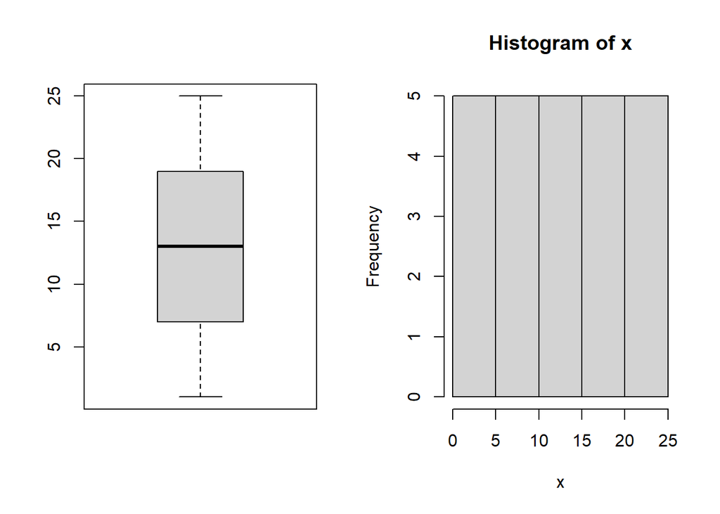

```r
x <- c(1:25, NA)
par(mfrow = c(1, 2))
boxplot(x)
hist(x)
```

## What are objects in your workspace?

```r
objects()
```

```
## [1] "a" "b" "x"
```

```r
ls()
```

```
## [1] "a" "b" "x"
```

If you want to delete some objects, you can type:

```r
rm(x)
objects()
```

```
## [1] "a" "b"
```

# **2. Introduction to Matrix**

## **2-1 Construct a matrix**

## Construct a matrix by row

```r
a<- 1:5
b<- 6:10
c<- 11:15
d<- 16:20
# construct a matrix, use rbind
M1<- rbind(a, b, c, d)
M1
```

```
##   [,1] [,2] [,3] [,4] [,5]
## a    1    2    3    4    5
## b    6    7    8    9   10
## c   11   12   13   14   15
## d   16   17   18   19   20
```

## Contruct a matrix by column

```r
# use cbind
M2<-cbind(a, b, c, d)
M2
```

```
##      a  b  c  d
## [1,] 1  6 11 16
## [2,] 2  7 12 17
## [3,] 3  8 13 18
## [4,] 4  9 14 19
## [5,] 5 10 15 20
```

```r
# dim is dimension
dim(M1)
```

```
## [1] 4 5
```

```r
dim(M2)
```

```
## [1] 5 4
```

## Constrict a matrix by a long vector

```r
x <-1:15
# use matrix(x, nrow = , ncol= )
matrix(x, nrow = 3, ncol= 5)
```

```
##      [,1] [,2] [,3] [,4] [,5]
## [1,]    1    4    7   10   13
## [2,]    2    5    8   11   14
## [3,]    3    6    9   12   15
```

```r
# use matrix(x, nrow = , ncol= , byrow = TRUE)
matrix(x, nrow = 3, ncol= 5, byrow = TRUE)
```

```
##      [,1] [,2] [,3] [,4] [,5]
## [1,]    1    2    3    4    5
## [2,]    6    7    8    9   10
## [3,]   11   12   13   14   15
```

## Features for a matrix

```r
colnames(M1)
```

[output not shown]

```r
rownames(M1)
```

```
## [1] "a" "b" "c" "d"
```

```r
colnames(M1)<-c('v1','v2','v3','v4','v5')
M1
```

```
##   v1 v2 v3 v4 v5
## a  1  2  3  4  5
## b  6  7  8  9 10
## c 11 12 13 14 15
## d 16 17 18 19 20
```

## **2-2 Extract elements from a matrix**

We still use “[ ]” to extract elements from a matrix, but using a “,” to identify the locations of row and column seperately.

```r
M1[2, 4]
```

```
## [1] 9
```

```r
M1[c(2,3), 4]
```

```
##  b  c
##  9 14
```

```r
M1[c(2,3), c(1,2)]
```

```
##   v1 v2
## b  6  7
## c 11 12
```

## Extract a row or a column from a matrix

```r
M1[ , 2]
```

```
##  a  b  c  d
##  2  7 12 17
```

```r
M1[2, ]
```

```
## v1 v2 v3 v4 v5
##  6  7  8  9 10
```

```r
M1[c(1,2), ]
```

```
##   v1 v2 v3 v4 v5
## a  1  2  3  4  5
## b  6  7  8  9 10
```

```r
M1[ ,c(1,2)]
```

```
##   v1 v2
## a  1  2
## b  6  7
## c 11 12
## d 16 17
```

```r
M1  ## consider as a vector ordered by column
```

```
##   v1 v2 v3 v4 v5
## a  1  2  3  4  5
## b  6  7  8  9 10
## c 11 12 13 14 15
## d 16 17 18 19 20
```

```r
M1[5]  ## you will get the 1st element from the 2nd column
```

```
## [1] 2
```

```r
M1[13]  ##the 1st element from the 4th column
```

```
## [1] 4
```

## **2-3 Evaluation of Matrix**

## Simple evaluation on matrix

```r
A <- matrix(c(1:4), 2, 2)
A + 3
```

```
##      [,1] [,2]
## [1,]    4    6
## [2,]    5    7
```

```r
A * 5
```

```
##      [,1] [,2]
## [1,]    5   15
## [2,]   10   20
```

```r
A / 4
```

```
##      [,1] [,2]
## [1,] 0.25 0.75
## [2,] 0.50 1.00
```

```r
B <- matrix(c(5:8), 2, 2)
A + B
```

```
##      [,1] [,2]
## [1,]    6   10
## [2,]    8   12
```

```r
A * B
```

```
##      [,1] [,2]
## [1,]    5   21
## [2,]   12   32
```

## Summary each column or each row

```r
C <- matrix(1:9, 3, 3)
colSums(C)
```

```
## [1]  6 15 24
```

```r
rowSums(C)
```

```
## [1] 12 15 18
```

```r
colMeans(C)
```

```
## [1] 2 5 8
```

```r
rowMeans(C)
```

```
## [1] 4 5 6
```

```r
t(c)  ## Transpose
```

```
##      [,1] [,2] [,3] [,4] [,5]
## [1,]   11   12   13   14   15
```

## Matrix multiplication

```r
A <- matrix(c(1:4), 2, 2)
B <- matrix(c(5:8), 2, 2)
A %*% B
```

```
##      [,1] [,2]
## [1,]   23   31
## [2,]   34   46
```

## Diagonal matrix and Determinant of a matrix

```r
A <- matrix(c(1:4), 2, 2)
B <- matrix(c(5:8), 2, 2)
c(diag(A),diag(B))
```

```
## [1] 1 4 5 8
```

```r
det(A)
```

```
## [1] -2
```

```r
det(B)
```

```
## [1] -2
```

## Inverse matrix

```r
A <- matrix(c(1:4), 2, 2)
B <- matrix(c(5:8), 2, 2)
solve(A)
```

```
##      [,1] [,2]
## [1,]   -2  1.5
## [2,]    1 -0.5
```

```r
solve(B)
```

```
##      [,1] [,2]
## [1,]   -4  3.5
## [2,]    3 -2.5
```

## Eigen system

```r
A <- matrix(c(1:4), 2, 2)
B <- matrix(c(5:8), 2, 2)
eigen(A)
```

```
## eigen() decomposition
## $values
## [1]  5.3722813 -0.3722813
##
## $vectors
##            [,1]       [,2]
## [1,] -0.5657675 -0.9093767
## [2,] -0.8245648  0.4159736
```

```r
eig.B<-eigen(B)
eig.B$values
```

```
## [1] 13.1520673 -0.1520673
```

```r
eig.B$vectors
```

```
##            [,1]       [,2]
## [1,] -0.6514625 -0.8053759
## [2,] -0.7586809  0.5927644
```

# **3. Introduction to vectors**

## **3-1 Numeric Vector**

## Creating vectors

Create two vectors and add one vector to another.

```r
vt1 <- c(1:5)
vt2 <- c(3:6)
vt2 <- c(vt2, vt1)
```

## Some common functions to vectors

```r
length(vt1)
```

```
## [1] 5
```

```r
vt1[3]
```

```
## [1] 3
```

```r
vt2[c(3,5,7)]
```

```
## [1] 5 1 3
```

```r
vt1[-2]
```

```
## [1] 1 3 4 5
```

```r
vt2[c(3:6)]
```

```
## [1] 5 6 1 2
```

## Vector arithmetic

```r
x<-c(3,6,9)
y<-c(1,2,3)
x*3
```

```
## [1]  9 18 27
```

```r
x-3
```

```
## [1] 0 3 6
```

```r
x^3
```

```
## [1]  27 216 729
```

```r
x^y
```

```
## [1]   3  36 729
```

```r
c(1, 1, 2, 2, 3, 3, 4, 4, 5, 5, 6, 6, 7, 7, 8, 8, 9, 9, 10, 10) %% 2:3
```

```
##  [1] 1 1 0 2 1 0 0 1 1 2 0 0 1 1 0 2 1 0 0 1
```

```r
c(1, 1, 2, 2, 3, 3, 4, 4, 5, 5, 6, 6, 7, 7, 8, 8, 9, 9, 10, 10) %% rep(2:3, 10)
```

```
##  [1] 1 1 0 2 1 0 0 1 1 2 0 0 1 1 0 2 1 0 0 1
```

## Simple patterned vectors

```r
rep(3,12)
```

```
##  [1] 3 3 3 3 3 3 3 3 3 3 3 3
```

```r
rep(seq(2,10,2), 2)
```

```
##  [1]  2  4  6  8 10  2  4  6  8 10
```

```r
rep(c(1, 4), c(3, 2))
```

```
## [1] 1 1 1 4 4
```

```r
rep(seq(2, 10, 2), rep(3, 5))
```

```
##  [1]  2  2  2  4  4  4  6  6  6  8  8  8 10 10 10
```

## Assign values into a vectors

```r
Xvector <- rep(NA, 6)
Xvector[3] <- 12
Xvector[c(4:6)] <- rep(1, 3)
Xvector
```

```
## [1] NA NA 12  1  1  1
```

```r
#delete NA
Xvector <- Xvector[-(1:2)]
Xvector
```

```
## [1] 12  1  1  1
```

```r
x <- c(1:25, NA)
mean(x, na.rm= TRUE)
```

```
## [1] 13
```

```r
median(x, na.rm= TRUE)
```

```
## [1] 13
```

```r
quantile(x,0.5, na.rm= TRUE)
```

```
## 50%
##  13
```

```r
summary(x)
```

```
##    Min. 1st Qu.  Median    Mean 3rd Qu.    Max.    NA's
##       1       7      13      13      19      25       1
```

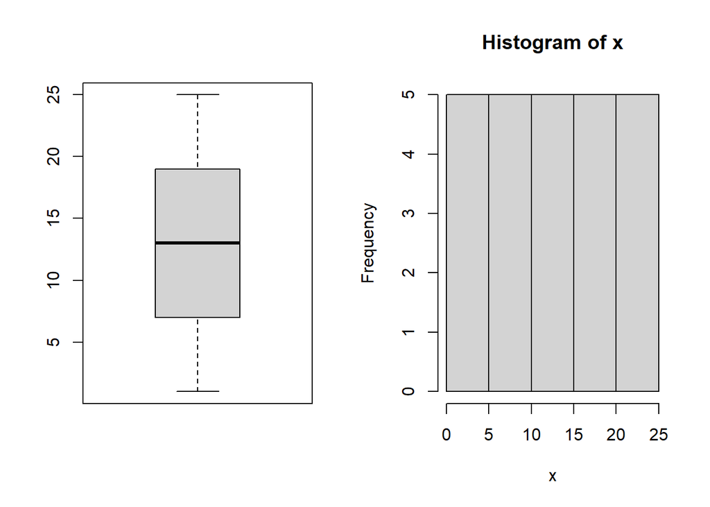

```r
par(mfrow= c(1,2))
boxplot(x)
hist(x)
```

## The objects in the workspace

```r
objects()
```

```
##  [1] "a"       "A"       "b"       "B"       "c"       "C"       "d"
##  [8] "eig.B"   "M1"      "M2"      "vt1"     "vt2"     "x"       "Xvector"
## [15] "y"
```

```r
ls()
```

```
##  [1] "a"       "A"       "b"       "B"       "c"       "C"       "d"
##  [8] "eig.B"   "M1"      "M2"      "vt1"     "vt2"     "x"       "Xvector"
## [15] "y"
```

```r
# if you want to delete some objects, you can type:
rm(x)
#Now, see again what you have in your workspace.
objects()
```

```
##  [1] "a"       "A"       "b"       "B"       "c"       "C"       "d"
##  [8] "eig.B"   "M1"      "M2"      "vt1"     "vt2"     "Xvector" "y"
```

## Simple patterned vectors

Use “seq()” and “rep()” to construct a vector with similar patterns.

```r
seq(1, 10, 2)
```

```
## [1] 1 3 5 7 9
```

```r
seq(1, 5, by = 0.5)
```

```
## [1] 1.0 1.5 2.0 2.5 3.0 3.5 4.0 4.5 5.0
```

```r
seq(1, 10, length.out =7 )
```

```
## [1]  1.0  2.5  4.0  5.5  7.0  8.5 10.0
```

```r
rep(3, 12)
```

```
##  [1] 3 3 3 3 3 3 3 3 3 3 3 3
```

```r
rep(seq(2, 10, 2), 2)
```

```
##  [1]  2  4  6  8 10  2  4  6  8 10
```

## Create a null or initial vector

Way1: Use *null vector*

```r
a <- c(3, 5, 9, 10)
b <- c(14, 15, 17)
V1 <- c()
V1 <- c(V1, a, b)
V1
```

```
## [1]  3  5  9 10 14 15 17
```

Way2: Use *“0”*

```r
a <- c(3, 5, 9, 10)
b <- c(14, 15, 17)
V2 <- rep(0, 7)
V2[1:4] <- a
V2
```

```
## [1]  3  5  9 10  0  0  0
```

Way3: Use *“NA”*

```r
a <- c(3, 5, 9, 10)
b <- c(14, 15, 17)
V3 <- rep(NA, 7)
V3[1:4] <- a
V3
```

```
## [1]  3  5  9 10 NA NA NA
```

When to use “c( )” and when to use a vector with known length?  
* c( ): Easy to add a value into the vector; need not know the length. *rep(NA, n): With known length and the position of elements.

## Elements in vectors

- Use “unique( )” to return the elements that appear at least one time. * Use “table( )” to count the number of each element from the vector.

```r
b<- c(1,1,1,1,4,5,7,9)
unique(b)
```

```
## [1] 1 4 5 7 9
```

```r
table(b)
```

```
## b
## 1 4 5 7 9
## 4 1 1 1 1
```

## Set operations

```r
a<- c(3,1,4,8,9)
b<-c(25,1,3,56,7)
union(a,b)
```

```
## [1]  3  1  4  8  9 25 56  7
```

```r
intersect(a,b)
```

```
## [1] 3 1
```

```r
# vector a - interest(a,b)
setdiff(a,b)
```

```
## [1] 4 8 9
```

```r
setequal(a,b)
```

```
## [1] FALSE
```

## Sorting and ordering of a vector

From small to large values, use “sort( )” or “order( )” to sort a vector or get the position of sorting of a vector. * *sort(x, decreasing = FALSE, …)*

```r
a<- c(2,4,8,6,7,12,56,89)
sort(a)
```

```
## [1]  2  4  6  7  8 12 56 89
```

```r
sort(a,decreasing = FALSE)
```

```
## [1]  2  4  6  7  8 12 56 89
```

- *order(…, na.last = TRUE, decreasing = FALSE)*  
  Get the position (index) of sorting of a vector

```r
a<- c(2,4,8,6,7,12,56,89)
inc.order <- order(a)
inc.order
```

```
## [1] 1 2 4 5 3 6 7 8
```

```r
a[inc.order]
```

```
## [1]  2  4  6  7  8 12 56 89
```

```r
dec.order <- order(a, decreasing = TRUE)
dec.order
```

```
## [1] 8 7 6 3 5 4 2 1
```

```r
a[dec.order]
```

```
## [1] 89 56 12  8  7  6  4  2
```

## Change values in a vector

```r
a<- c(2,4,8,6,7,12,56,89)
a[5]<- -3
a  ## Change the 5th element to -3
```

```
## [1]  2  4  8  6 -3 12 56 89
```

```r
vt1<-c(1:10)
vt1[-2]
```

```
## [1]  1  3  4  5  6  7  8  9 10
```

```r
vt1[-c(3:6)]
```

```
## [1]  1  2  7  8  9 10
```

## **3-2 Character Vectors**

```r
"Hello World!!!"
```

```
## [1] "Hello World!!!"
```

```r
print("Hello R World!!!")
```

```
## [1] "Hello R World!!!"
```

## Split a string

use *strsplt(x, split)*

```r
TEXT1 <- "Let's go to a game."
strsplit (TEXT1, " ")
```

```
## [[1]]
## [1] "Let's" "go"    "to"    "a"     "game."
```

```r
TEXT2 <- "Hurry! We are late!"
strsplit (TEXT2, "!")
```

```
## [[1]]
## [1] "Hurry"        " We are late"
```

## Lowercase and uppercase

- toupper(): change to uppercase
- tolower(): change to lowercase

```r
toupper(TEXT1)
```

```
## [1] "LET'S GO TO A GAME."
```

```r
tolower(TEXT2)
```

```
## [1] "hurry! we are late!"
```

## Character vectors

- Character vector: the vector is made up of strings of characters.
- All elements of a vector must be of the same type.

```r
more.colors <- c(colors, "green", "cyan")
more.colors
```

```
## [[1]]
## function (distinct = FALSE)
## {
##     c <- .Call(C_colors)
##     if (distinct)
##         c[!duplicated(t(col2rgb(c)))]
##     else c
## }
## <bytecode: 0x000000001ce65c48>
## <environment: namespace:grDevices>
##
## [[2]]
## [1] "green"
##
## [[3]]
## [1] "cyan"
```

- An attempt to mix data types in a vector

```r
z <- c("red", "green", 12)
z
```

```
## [1] "red"   "green" "12"
```

## Basic operations foe character vectors

- to take substrings, use ‘substr( )’.

```r
colors <- c("red", "yellow", "blue")
substr(colors, 1, 3)
```

```
## [1] "red" "yel" "blu"
```

- To search a string from a vector, use “grep()”, which is “Global Regular Expression Print”. It returns the locations of the desired patterns.

```r
grep("y", more.colors)
```

```
## [1] 3
```

```r
grep("e", more.colors)
```

```
## [1] 1 2
```

- How to show the whole character from grep()?

```r
y.in.V <- grep("y", more.colors)
e.in.V <- grep("e", more.colors)
more.colors[y.in.V]
```

```
## [[1]]
## [1] "cyan"
```

```r
E.in.V <- grep("E", more.colors)
more.colors[E.in.V]
```

```
## [[1]]
## function (distinct = FALSE)
## {
##     c <- .Call(C_colors)
##     if (distinct)
##         c[!duplicated(t(col2rgb(c)))]
##     else c
## }
## <bytecode: 0x000000001ce65c48>
## <environment: namespace:grDevices>
```

- To building up strings, use “paste()”.

```r
paste(colors, "line") ## with space
```

```
## [1] "red line"    "yellow line" "blue line"
```

```r
paste(colors, "line", sep = "" ) ## no space
```

```
## [1] "redline"    "yellowline" "blueline"
```

```r
## use ";" to seperate strings
paste("I like", colors, collapse = "; ")
```

```
## [1] "I like red; I like yellow; I like blue"
```

## Factors

factor(): factor(x = character())

```r
colors <- c("red", "yellow", "blue")
f.c <- factor(colors)
f.c
```

```
## [1] red    yellow blue
## Levels: blue red yellow
```

```r
levels(f.c)
```

```
## [1] "blue"   "red"    "yellow"
```

```r
as.integer(f.c)
```

```
## [1] 2 3 1
```

## **3-3 Logical Vectors**

## Logical words and numbers

```r
TRUE
```

```
## [1] TRUE
```

```r
FALSE
```

```
## [1] FALSE
```

```r
T
```

```
## [1] TRUE
```

```r
F
```

```
## [1] FALSE
```

```r
## T and F are global variables whose initial values set to TRUE and FALSE
c(3 < 5, 3 > 5)
```

```
## [1]  TRUE FALSE
```

```r
c(3 <= 5, 3 >= 5)
```

```
## [1]  TRUE FALSE
```

```r
3 != 5
```

```
## [1] TRUE
```

## Boolean operations

```r
A <- c(T, T, F, T, F)
B <- c(3, 1, 5, 4, 7)
B[A]
```

```
## [1] 3 1 4
```

```r
!A
```

```
## [1] FALSE FALSE  TRUE FALSE  TRUE
```

```r
B[!A]
```

```
## [1] 5 7
```

How many TRUE (or FALSE) in the vector?

```r
A <- c(T, T, F, T, F)
sum(A)
```

```
## [1] 3
```

```r
sum(!A)
```

```
## [1] 2
```

## Logical vector

Compare the same location of elements individually.

```r
B <- c(3, 1, 5, 4, 7)
C <- c(23, 1, 44, 5, 3)
B == C
```

```
## [1] FALSE  TRUE FALSE FALSE FALSE
```

- If the lengths of two objects are different, we will eceive the warning. ‘longer object length is not a multiple of shorter object length.’

```r
B <- c(3, 1, 5, 4, 7)
D <- c(2, 5 ,6, 10)
B == D
```

```
## Warning in B == D: 較長的物件長度並非較短物件長度的倍數
```

```
## [1] FALSE FALSE FALSE FALSE FALSE
```

## ‘is.’ series

“is.XYZ()” is any comparison to the type “XYZ” of an object. * is.null() * is.na() * is.nan() * is.inﬁnite() * is.character() * is.integer() * is.numeric()

```r
is.null(c())
```

```
## [1] TRUE
```

```r
c(is.na(NA), is.na(2))
```

```
## [1]  TRUE FALSE
```

```r
x1 <- 1:5
x2 <- c(1:3, 2.2)
x3 <- colors
c(is.integer(x1), is.numeric(x1), is.double(x1))
```

```
## [1]  TRUE  TRUE FALSE
```

```r
c(is.integer(x2), is.numeric(x2), is.double(x2))
```

```
## [1] FALSE  TRUE  TRUE
```

```r
c(is.character(x3), is.numeric(x3))
```

```
## [1]  TRUE FALSE
```

## Examine the type of a vector

Use ‘class( )’ to identify the type of a vectors.

```r
a <- c(3, 4, 2, 7, 10, 23, 8, 9, 11)
b <- c("red", "yellow", "blue")
c <- c(TRUE, FALSE)
d <- f.c
c(class(a), class(b), class(c), class(d))
```

```
## [1] "numeric"   "character" "logical"   "factor"
```

# **4. Matrix**

## **4-1 Construct a matrix**

## Construct a matrix by row

- use *‘rbind( )’*

```r
a <- 1:5
b <- 6:10
c <- 11:15
d <- 16:20
M1 <- rbind(a, b, c, d)
M1
```

```
##   [,1] [,2] [,3] [,4] [,5]
## a    1    2    3    4    5
## b    6    7    8    9   10
## c   11   12   13   14   15
## d   16   17   18   19   20
```

## Construct a matrix by column

- use *‘cbind’*

```r
M2 <- cbind(a, b, c, d)
M2
```

```
##      a  b  c  d
## [1,] 1  6 11 16
## [2,] 2  7 12 17
## [3,] 3  8 13 18
## [4,] 4  9 14 19
## [5,] 5 10 15 20
```

## Construct a matrix by a long vector

- use *matrix(x,nrow= ,ncol= )*

```r
X <- 1:20
matrix(X, nrow = 4, ncol = 5)  ## order by column
```

```
##      [,1] [,2] [,3] [,4] [,5]
## [1,]    1    5    9   13   17
## [2,]    2    6   10   14   18
## [3,]    3    7   11   15   19
## [4,]    4    8   12   16   20
```

```r
matrix(X, nrow = 5, ncol = 4)
```

```
##      [,1] [,2] [,3] [,4]
## [1,]    1    6   11   16
## [2,]    2    7   12   17
## [3,]    3    8   13   18
## [4,]    4    9   14   19
## [5,]    5   10   15   20
```

```r
matrix(X, nrow = 4, ncol = 5, byrow = TRUE)  ##order by row
```

```
##      [,1] [,2] [,3] [,4] [,5]
## [1,]    1    2    3    4    5
## [2,]    6    7    8    9   10
## [3,]   11   12   13   14   15
## [4,]   16   17   18   19   20
```

```r
matrix(X, nrow = 5, ncol = 4, byrow = TRUE)
```

```
##      [,1] [,2] [,3] [,4]
## [1,]    1    2    3    4
## [2,]    5    6    7    8
## [3,]    9   10   11   12
## [4,]   13   14   15   16
## [5,]   17   18   19   20
```

## Features for a matrix

- dim( )
- colnames( )
- rownames( )
- dimnames( )

```r
M1
```

```
##   [,1] [,2] [,3] [,4] [,5]
## a    1    2    3    4    5
## b    6    7    8    9   10
## c   11   12   13   14   15
## d   16   17   18   19   20
```

```r
dim(M1)
```

```
## [1] 4 5
```

```r
colnames(M1)
```

[output not shown]

```r
colnames(M1)<- c("V1", "V2", "V3", "V4", "V5")
dimnames(M1)
```

```
## [[1]]
## [1] "a" "b" "c" "d"
##
## [[2]]
## [1] "V1" "V2" "V3" "V4" "V5"
```

## **4-2 Extract elements from a matrix**

We still use “[ ]” to extract elements from a matrix, but using a “,” to identify the locations of row and column seperately.

```r
M1[2, 4]
```

```
## [1] 9
```

```r
M1[c(2, 4), 3]
```

```
##  b  d
##  8 18
```

```r
M1[c(2, 4), c(3, 5)]
```

```
##   V3 V5
## b  8 10
## d 18 20
```

## Extract a row or column from a matrix

```r
M1[, 4]
```

```
##  a  b  c  d
##  4  9 14 19
```

```r
M1[c(2, 4), ]; M1[, c(3, 5)]
```

```
##   V1 V2 V3 V4 V5
## b  6  7  8  9 10
## d 16 17 18 19 20
```

```
##   V3 V5
## a  3  5
## b  8 10
## c 13 15
## d 18 20
```

```r
M1
```

```
##   V1 V2 V3 V4 V5
## a  1  2  3  4  5
## b  6  7  8  9 10
## c 11 12 13 14 15
## d 16 17 18 19 20
```

```r
M1[5]
```

```
## [1] 2
```

```r
M1[13]
```

```
## [1] 4
```

Recall M1. The names of rows are a, b, c, and d. Take the rows of b and c.

The names of columns are V1, V2, V3, V4, and V5. Take the rows of b and c and the columns of V2 and V5.

```r
M1[c("b", "c"), ]
```

```
##   V1 V2 V3 V4 V5
## b  6  7  8  9 10
## c 11 12 13 14 15
```

```r
M1[c("b", "c"), c("V2", "V5")]
```

```
##   V2 V5
## b  7 10
## c 12 15
```

# **5.Control Flow**

## **5-1 The for() loop**

## For() loop

When to use? See patterns of behaviour, not just a single instance. The for() statement allows one to specify that a certain operation should be repeated a fixed number of times.

Syntax  
for (index in vector) commands  
* index: the index is changed each time * vector: it includes all possible cases * commands: actions

### * Example

Construct a vector as
$$X_{n+1} = 2X_n+3$$
where $X_0$ = 3, n=1, 2, 3, 4, 5, 6, 7

- Version1

```r
vec.X.v1 <- c()
Xn <- 3
for(n in 1:7){
Xn <- 2*Xn + 3
vec.X.v1 <- c(vec.X.v1, Xn)
}
vec.X.v1
```

```
## [1]   9  21  45  93 189 381 765
```

- Version2

```r
vec.X.v2 <- rep(NA, 8)
vec.X.v2[1] <- 3
for(n in 1:7){
vec.X.v2[n+1] <- 2 * vec.X.v2[n] + 3
}
vec.X.v2
```

```
## [1]   3   9  21  45  93 189 381 765
```

```r
vec.X.v2[-1]
```

```
## [1]   9  21  45  93 189 381 765
```

## Evaluate n!

$n!=n*(n-1)*(n-2)*...*2*1$

Try n = 10

```r
n <- 10
ans <- 1
for(j in n:1){
ans <- ans * j
}
ans
```

```
## [1] 3628800
```

```r
factorial(n) ## 算階層的Func.
```

```
## [1] 3628800
```

## Random number generator

Random samples from [0, 1] by the linear congruntial generator.

$x_n=(ax_{n−1}+c)\ mod\ m$

Let $x_0$ = 3, a = 5, c = 7, and m = 501. Find $x_i$ , where i = 1, . . . , n

- Version1

```r
x0 <- 3; a <- 5; c <- 7; m <- 501
X <- rep(NA, 10)
for(j in 1:10){
x0 <- (a*x0+c) %% m
X[j] <- x0
}
X
```

```
##  [1]  22 117  91 462 313  69 352 264 325 129
```

```r
round(X/m, 2)
```

```
##  [1] 0.04 0.23 0.18 0.92 0.62 0.14 0.70 0.53 0.65 0.26
```

- Version2

```r
x0 <- 3; a <- 5; c <- 7; m <- 501
X <- rep(NA, 11)
X[1] <- x0
for(j in 1:10){
X[j + 1] <- (a*X[j] + c) %% m
}
X[2:11]
```

```
##  [1]  22 117  91 462 313  69 352 264 325 129
```

```r
round(X/m, 2)
```

```
##  [1] 0.01 0.04 0.23 0.18 0.92 0.62 0.14 0.70 0.53 0.65 0.26
```

Given a matrix X = $\left[ \begin{array}{cc} 3&2&4&5&3 \\ 2&6&8&10&4 \\ 1&4&6&8&3 \\ 2&1&2&6&4 \\ \end{array} \right]$

evaluate the mean for each row.

```r
A <- matrix(c(3, 2, 1, 2, 2, 6, 4, 1,
4, 8, 6, 2, 5, 10, 8, 6,
3, 4, 3, 4), 4, 5)
nr <- dim(A)[1]
m <- c()
for(j in 1:nr){
m <- c(m, mean(A[j, ]))
}
m
```

```
## [1] 3.4 6.0 4.4 3.0
```

## **5-2 The if() statement**

**Syntax**

- *One condition*: if (condition) {commands when TRUE}  
  if (condition) {commands when TRUE} else {commands when FALSE}
- *Multiple conditions*:  
  if (condition 1){  
  commands when condition1 is TRUE  
  } **else if** (condition2) {  
  commands when condition2 is TRUE  
  }else{  
  commands when condition1 and condition2 are FALSE  
  }

## Count the number of each class

```r
basket <- c("r", "b", "y", "y", "y", "r", "r", "b")
n.r <- 0; n.b <- 0; n.y <- 0
for(i in 1:length(basket)){
if(basket[i] == "r"){
n.r <- n.r + 1
}else if(basket[i] == "b"){
n.b <- n.b + 1
}else{
n.y <- n.y + 1
}
}
c(n.r, n.b, n.y)
```

```
## [1] 3 2 3
```

## Count the number of each class by vectorization

```r
ind.r <- basket == "r"
ind.b <- basket == "b"
ind.y <- basket == "y"
c(sum(ind.r), sum(ind.b), sum(ind.y))
```

```
## [1] 3 2 3
```

## Re-assign the value to the class

Let “r” be 1, “b” be 2, and “y” be 3.

- Way1

```r
v.basket <- rep(NA, length(basket))
for(i in 1:length(basket)){
if(basket[i] == "r"){
v.basket[i] <- 1
}else if(basket[i] == "b"){
v.basket[i] <- 2
}else{
v.basket[i] <- 3
}
}
v.basket
```

```
## [1] 1 2 3 3 3 1 1 2
```

- Way2: by vectorization

```r
v.basket <- rep(NA, length(basket))
ind.r <- basket == "r"
ind.b <- basket == "b"
ind.y <- basket == "y"
v.basket[ind.r] <- 1
v.basket[ind.b] <- 2
v.basket[ind.y] <- 3
v.basket
```

```
## [1] 1 2 3 3 3 1 1 2
```

- Way3: by ifelse()

Use:  
*ifelse(condition, commands when TRUE, commands when FALSE)*

```r
v.basket <- ifelse(basket == "r", 1, ifelse(basket == "b", 2, 3))
v.basket
```

```
## [1] 1 2 3 3 3 1 1 2
```

## **5-3 The while() loop**

**Syntax**

*while (condition) statements*

- If the condition evaluates to FALSE, nothing more is done. If it evaluates to TRUE the statements are executed, condition is evaluated again, and the process is repeated.

## Fibonacci numbers (1)

List all Fibonacci numbers less than 100.

```r
Fib1 <- 1
Fib2 <- 1
Fibonacci <- c(Fib1)
while (Fib2 < 100) {
Fibonacci <- c(Fibonacci, Fib2)
Fib1 <- Fibonacci[length(Fibonacci) - 1]
Fib2 <- Fib1 + Fibonacci[length(Fibonacci)]
}
Fibonacci
```

```
##  [1]  1  1  2  3  5  8 13 21 34 55 89
```

## Flip a coin

Let 0 be a tail and 1 be a head. Count the total number of flipping until each success occurs.

```r
coin <- c(0, 0, 0, 0, 0, 0, 1, 0, 1, 0, 1, 0,
1, 1, 0, 1, 1, 0, 0, 0, 1, 0, 1, 0,
0, 0, 0, 0, 0, 0, 1)
N <- c(); j <- 1
while(j <= length(coin)){
n.fail <- 0
while(coin[j] != 1){
n.fail <- n.fail + 1
j <- j + 1
}
N <- c(N, n.fail + 1)
j <- j + 1
}
N
```

```
##  [1] 7 2 2 2 1 2 1 4 2 8
```

## **5-4 Break, repeat, next**

- **break**

*if (condition) break*

The break statement causes the loop to terminate immediately. break statements can also be used in for() and while() loops.

- **repeat**

*repeat { statements }*

Use “repeat” to repeat until we execute a break statement

- **next** The next statement causes control to return immediately to the top of the loop; it can also be used in any loop.

## Fibonacci numbers(2)

List all Fibonacci numbers

```r
Fib1 <- 1
Fib2 <- 1
Fibonacci <- c(Fib1)
for(j in 1:1000){
if(Fib2 < 100){
Fibonacci <- c(Fibonacci, Fib2)
Fib1 <- Fibonacci[length(Fibonacci) - 1]
Fib2 <- Fib1 + Fibonacci[length(Fibonacci)]
}else{
break
}
}
Fibonacci
```

```
##  [1]  1  1  2  3  5  8 13 21 34 55 89
```

## Fibonacci numbers (3)

```r
Fib1 <- 1
Fib2 <- 1
Fibonacci <- c(Fib1)
repeat
{
if(Fib2 < 100){
Fibonacci <- c(Fibonacci, Fib2)
Fib1 <- Fibonacci[length(Fibonacci) - 1]
Fib2 <- Fib1 + Fibonacci[length(Fibonacci)]
}else{
break
}
}
Fibonacci
```

```
##  [1]  1  1  2  3  5  8 13 21 34 55 89
```

## Fibonacci numbers (4)

```r
Fib1 <- 1
Fib2 <- 1
Fibonacci <- c(Fib1)
repeat
{
if(Fib2 >= 100) break
Fibonacci <- c(Fibonacci, Fib2)
Fib1 <- Fibonacci[length(Fibonacci) - 1]
Fib2 <- Fib1 + Fibonacci[length(Fibonacci)]
}
Fibonacci
```

```
##  [1]  1  1  2  3  5  8 13 21 34 55 89
```

## Fibonacci numbers (5)

```r
Fib1 <- 1
Fib2 <- 1
Fibonacci <- c(Fib1)
for(j in 1:100){
if(Fib2 >= 100) next
Fibonacci <- c(Fibonacci, Fib2)
Fib1 <- Fibonacci[length(Fibonacci) - 1]
Fib2 <- Fib1 + Fibonacci[length(Fibonacci)]
#print(j)
}
Fibonacci
```

```
##  [1]  1  1  2  3  5  8 13 21 34 55 89
```

# **6. Function**

## **6-1 Use Source()**

## Source()

- Create a new script for your function or codes.
- Save the script named as “XXX.R” and use **source( )** to run the code
- Remember to use **print( )** or **cat( )** so that your final answer will be shown

### Example

```r
x <- c(0.8933, 0.2344, 0.0764, 0.7736)
x.percent <- round(100*x, digits = 1)
x.show <- paste(x.percent, "%", sep = "")
print(x.show)
```

```
## [1] "89.3%" "23.4%" "7.6%"  "77.4%"
```

```r
cat(x.show)
```

```
## 89.3% 23.4% 7.6% 77.4%
```

## print( ) & cat( )

**print( )** shows with " " between characters  
**cat()** shows without " " between characters. You can add ”" to make characters in a new line

### example

Find all perfect numbers smaller than 100.

```r
k <- 1
while(k < 100){
fac <- c()
for(j in 1:k){
if((k %% j) == 0) fac <- c(fac, j)
}
if(k == sum(fac[-length(fac)])){
out <- paste(paste(k, "=", sep=" "),
paste(fac[-length(fac)], collapse = " + "),
sep = " ")
print(out)
}
k <- k+1
}
```

```
## [1] "6 = 1 + 2 + 3"
## [1] "28 = 1 + 2 + 4 + 7 + 14"
```

or use cat()

```r
k <- 1
while(k < 100){
fac <- c()
for(j in 1:k){
if((k %% j) == 0){
fac <- c(fac, j)
}
}
if(k == sum(fac[-length(fac)])){
cat(paste(k, "=", sep=" "),
paste(fac[-length(fac)], collapse = " + "), "\n")
}
k <- k+1
}
```

```
## 6 = 1 + 2 + 3
## 28 = 1 + 2 + 4 + 7 + 14
```

use cat() but without ”"

```r
k <- 1
while(k < 100){
fac <- c()
for(j in 1:k){
if((k %% j) == 0){
fac <- c(fac, j)
}
}
if(k == sum(fac[-length(fac)])){
cat(paste(k, "=", sep=" "),
paste(fac[-length(fac)], collapse = " + "))
}
k <- k+1
}
```

```
## 6 = 1 + 2 + 328 = 1 + 2 + 4 + 7 + 14
```

## **6-2 Use function( ) with one single input**

Use function( ) when you only have one main code for evaluation and multiple possible input

```r
make.percent <- function(x){
x.percent <- round(100*x, digits = 1)
x.show <- paste(x.percent, "%", sep = "")
cat(x.show)
}
make.percent(c(0.8933, 0.2344, 0.0764, 0.7736))
```

```
## 89.3% 23.4% 7.6% 77.4%
```

```r
# we can not express the answer by
ans <- make.percent(c(0.8933, 0.2344, 0.0764, 0.7736))
```

```
## 89.3% 23.4% 7.6% 77.4%
```

```r
ans
```

[output not shown]

## return( ) in the function( )

You must tell what will be return when you use the function by **return( )** or **invisible( )**. If you don’t put return( ) at the end of the function, it will treat the last line as the result automatically.

```r
f <- function(x){
return(3*x + 2)
}
f(2)
```

```
## [1] 8
```

## **6-3 Use function( ) with multiple input variables**

Use function( ) when you only have one main code for evaluation and multiple possible input, like $f(x,y)={x^2}+{y^2}, x,y=2,3,4$ f means a name of a function of input x and y when x, y = 2, 3, 4.

```r
f <- function(x, y){
x^2 + y^2
}
f(2, 2); f(2, 3); f(2, 4)
```

```
## [1] 8
```

```
## [1] 13
```

```
## [1] 20
```

### Example: percent

```r
make.percent <- function(x, x.digits){
x.percent <- round(100*x, digits = x.digits)
x.show <- paste(x.percent, "%", sep = "")
return(x.show)
}
make.percent(c(0.8933, 0.2344, 0.0764, 0.7736), 0)
```

```
## [1] "89%" "23%" "8%"  "77%"
```

```r
make.percent(c(0.8933, 0.2344, 0.0764, 0.7736), 2)
```

```
## [1] "89.33%" "23.44%" "7.64%"  "77.36%"
```

### Example: perfect number

Find all perfect numbers between 10 and 10000.

```r
perfect.number <- function(a, b){
k <- a
res <- c()
while(k < b){
fac <- c()
for(j in 1:k){
if((k %% j) == 0) fac <- c(fac, j)
}
if(k == sum(fac[-length(fac)])) {
res <- c(res, k)}
k <- k+1
}
return(res)
}
perfect.number(10, 10000)
```

```
## [1]   28  496 8128
```

## Set a default in the function

Add the settings of default in the arguments of input variables. f <- function(x = 1, y = 10){. . .}

### Example: percent

```r
make.percent <- function(x, x.digits = 0){
x.percent <- round(100*x, digits = x.digits)
x.show <- paste(x.percent, "%", sep = "")
return(x.show)
}
make.percent(c(0.8933, 0.2344, 0.0764, 0.7736))
```

```
## [1] "89%" "23%" "8%"  "77%"
```

## **6-4 Use function( ) and return multiple output**

## list()

a collection of multiple types of objects, like vectors, characters, numbers, lists,. . . .

```r
X <- list(a = 3, b = c(1,2,3,4,5), c = c("A", "B"))
X
```

```
## $a
## [1] 3
##
## $b
## [1] 1 2 3 4 5
##
## $c
## [1] "A" "B"
```

Use $ or [[ ]].

- **$**: the name of the element
- **[[ ]]**: the location or the name of the element

```r
X <- list(a = 3, b = c(1,2,3,4,5), c = c("A", "B"))
X$a
```

```
## [1] 3
```

```r
X[[2]]
```

```
## [1] 1 2 3 4 5
```

```r
X[["c"]]
```

```
## [1] "A" "B"
```

## Create a list

```r
try.list <- list() ## a null list
length(try.list) <- 2 ## assign the size to the list
try.list[[1]] <- seq(0, 10, length.out = 3) ## without name
try.list$square <- seq(0, 10, length.out = 3)^2 ## with name
try.list
```

```
## [[1]]
## [1]  0  5 10
##
## [[2]]
## NULL
##
## $square
## [1]   0  25 100
```

Exact element from the list

```r
try.list[[3]]
```

```
## [1]   0  25 100
```

```r
try.list$square
```

```
## [1]   0  25 100
```

```r
names(try.list)
```

```
## [1] ""       ""       "square"
```

```r
length(try.list)
```

```
## [1] 3
```

## Use function() and list()

### Example: perfect number

```r
perfect.number <- function(a, b){
k <- a
res <- c()
ans <- list()
while(k < b){
fac <- c()
for(j in 1:k){
if((k %% j) == 0) fac <- c(fac, j)
}
if(k == sum(fac[-length(fac)])) {
res <- c(res, k)
ans[[paste(k)]] <- fac[-length(fac)]
}
k <- k+1
}
ans$number <- res
return(ans)
}
Ans <- perfect.number(1, 100)
Ans
```

```
## $`6`
## [1] 1 2 3
##
## $`28`
## [1]  1  2  4  7 14
##
## $number
## [1]  6 28
```

```r
Ans[["28"]]
```

```
## [1]  1  2  4  7 14
```

## Partially shown multiple output

invisible(): hiding some output

```r
perfect.number <- function(a, b){
k <- a
res <- c()
ans <- list()
while(k < b){
fac <- c()
for(j in 1:k){
if((k %% j) == 0) fac <- c(fac, j)
}
if(k == sum(fac[-length(fac)])) {
res <- c(res, k)
ans[[paste(k)]] <- fac[-length(fac)]
}
k <- k+1
}
print(res)
ans$number <- res
return(invisible(ans))
}
Ans <- perfect.number(1, 100)
```

```
## [1]  6 28
```

```r
Ans
```

```
## $`6`
## [1] 1 2 3
##
## $`28`
## [1]  1  2  4  7 14
##
## $number
## [1]  6 28
```

# **7. Related to Data**

## **7-1 Data Frame**

- Most data sets are stored in R as data frames
- These are like matrices, but with the columns having their own names.
- Columns can be of different types from each other.

Use the **data.frame()** to construct data frames from vectors

### Example: Use Dataframe

```r
colors <- c("red", "yellow", "blue")
numbers <- c(1, 2, 3)
colors.and.numbers <- data.frame(colors, numbers,
more.numbers = c(4, 5, 6))
colors.and.numbers
```

```
##   colors numbers more.numbers
## 1    red       1            4
## 2 yellow       2            5
## 3   blue       3            6
```

Dataframe is different from matrix.

### Example: Use matrix

```r
X <- matrix(NA, 3, 3)
X[,1] <- c("red", "yellow", "blue")
X[,2] <- c(1, 2, 3)
X[,3] <- c(4, 5, 6)
colnames(X) <- c("colors", "numbers", "more.numbers")
X
```

```
##      colors   numbers more.numbers
## [1,] "red"    "1"     "4"
## [2,] "yellow" "2"     "5"
## [3,] "blue"   "3"     "6"
```

Use **str()** to examine the types of columns in the data frame.

```r
str(colors.and.numbers)
```

```
## 'data.frame':    3 obs. of  3 variables:
##  $ colors      : chr  "red" "yellow" "blue"
##  $ numbers     : num  1 2 3
##  $ more.numbers: num  4 5 6
```

## Types in a data frame: character

Change the type from factor to character by using**stringAsFactors = FALSE.**

```r
colors <- c("red", "yellow", "blue")
numbers <- c(1, 2, 3)
colors.and.numbers <- data.frame(colors, numbers,
more.numbers = c(4, 5, 6),
stringsAsFactors = FALSE)
str(colors.and.numbers)
```

```
## 'data.frame':    3 obs. of  3 variables:
##  $ colors      : chr  "red" "yellow" "blue"
##  $ numbers     : num  1 2 3
##  $ more.numbers: num  4 5 6
```

## More on data.frame(): add rows

Add column and row vectors into a data frame.  
* row: use **rbind()** * column: use the sign **$** or **cbind()**

```r
data1 <- data.frame(colors, numbers, more.numbers = c(4, 5, 6))
data1 <- rbind(data1, c("black", 3, 5))
#data1  ## Warning in `[<-.factor`(`*tmp*`, ri, value = "black"): invalid factor level, NA generated

data2 <- data.frame(colors, numbers, more.numbers = c(4, 5, 6),stringsAsFactors = FALSE)
data2 <- rbind(data2, c("black", 3, 5))
data2
```

```
##   colors numbers more.numbers
## 1    red       1            4
## 2 yellow       2            5
## 3   blue       3            6
## 4  black       3            5
```

## Comparison of two types

```r
str(data1)
```

```
## 'data.frame':    4 obs. of  3 variables:
##  $ colors      : chr  "red" "yellow" "blue" "black"
##  $ numbers     : chr  "1" "2" "3" "3"
##  $ more.numbers: chr  "4" "5" "6" "5"
```

```r
str(data2)
```

```
## 'data.frame':    4 obs. of  3 variables:
##  $ colors      : chr  "red" "yellow" "blue" "black"
##  $ numbers     : chr  "1" "2" "3" "3"
##  $ more.numbers: chr  "4" "5" "6" "5"
```

## More on data.frame(): add columns

```r
colors <- c("red", "yellow", "blue")
number1 <- c(1, 2, 3)
number2 <- c(10, 11, 12)
colors.and.numbers <- data.frame(colors, number1) ## construct data.frame
colors.and.numbers$more.numbers <- c(4, 5, 6) ## add one column
colors.and.numbers <- cbind(colors.and.numbers, number2) ## add one column
colors.and.numbers
```

```
##   colors number1 more.numbers number2
## 1    red       1            4      10
## 2 yellow       2            5      11
## 3   blue       3            6      12
```

## **7-2 Data input and output at hard disk**

- Change the directory: **setwd(“dir”)**
- Find the directory: **get()**

## Save and load the objects

- Suppose you have constructed some R objects, type **dump(objects, file = “XXX.R”)**

```r
X <- seq(0, 10, 0.1)
A <- 3
B <- mean(X)
dump(list = objects(), file = "all.R")
dump(c("A", "X"), file = "parts.R")
```

- To retrieve the objects in a future session, type **source(“XXX.R”)**
- To save *all* objects in the current workspace, type **save.image(“XXX.RData”)**
- To save *parts of* objects, type type **save(a, b, c, file = “XXX.RData”)**
- Use **load(“XXX.RData”)** to retrieve data

```r
X <- seq(0, 10, 0.1)
A <- 3
B <- mean(X)
#save.image("all.RData")
#save(A, B, "parts.RData")
#load("parts.RData")
#load("all.RData")
```

## Save data to a file

- You can save a matrix, a vector, or a data frame into two types of file, .txt (.dat) and .csv.
- Use **write.table(A, file = “XXX.txt”)**
- Use **write.csv(A, file = “XXX.csv”)**

## Read data from a file

- Use **read.table(file = “XXX.txt”)**
- Use **read.csv(file = “XXX.csv”)**

With names of columns in a .txt file, you should add **header = TRUE**

```r
#read.table("test.txt", header = TRUE)
```

## **7-3 R packages**

## Introduction to R packages

- Other than some basic functions, some developed methodologies and tools are provided in a way of packages. You can download them from CRAN or Github.
- To download a package, type **install.packages(“XXX”)**.
- Before using some functions in a downloaded package, you should call the package by typing **library(XXX)**.

## Use the functions in the installed packages

Try the function **fread( )**, which is similar to **read.table( )** but faster and more convenient

## **7-4 Tools for Help**

When you know the name of a function and you want to see how to use it, type **help(name)** or **?name**.

For example:

```r
help(mean)
```

```
## starting httpd help server ... done
```

```r
?median
```

A useful alternative to help() is the example() function

```r
example(mean)
```

```
##
## mean> x <- c(0:10, 50)
##
## mean> xm <- mean(x)
##
## mean> c(xm, mean(x, trim = 0.10))
## [1] 8.75 5.50
```

For finding help when you don’t know the function name, type **help.search()**.

```r
help.search("optimization")
```

# **8. R Graphics**

## **8-1 Statistical Figures**

## Graphics for descriptive statistics

- Histogram: **hist(x)**
- Boxplot: **boxplot(x)**
- Density plot: **plot(density(x))**

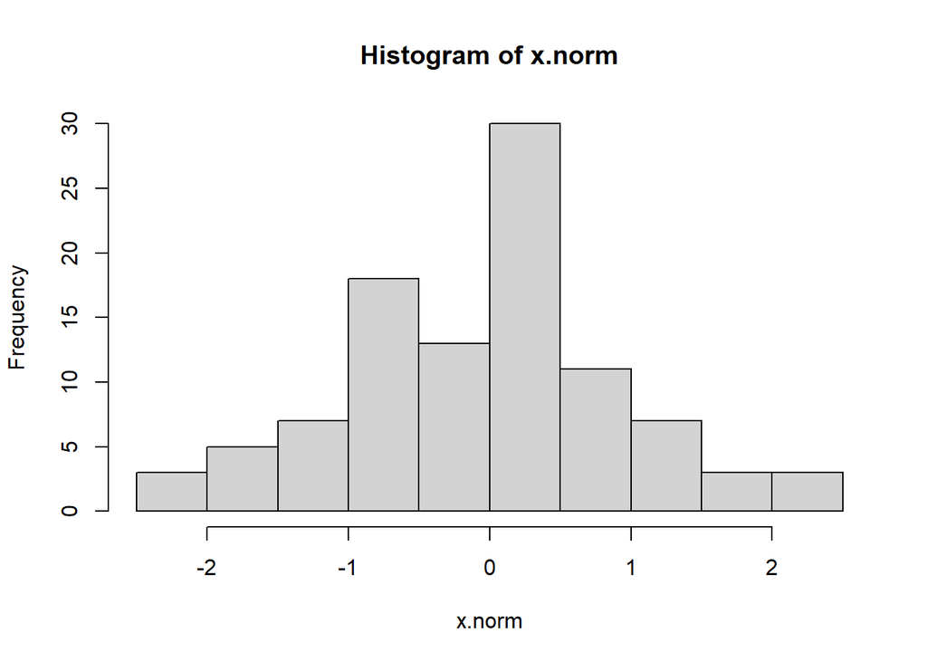

```r
x.norm <- rnorm(100, mean=0, sd=1)
hist(x.norm)
```

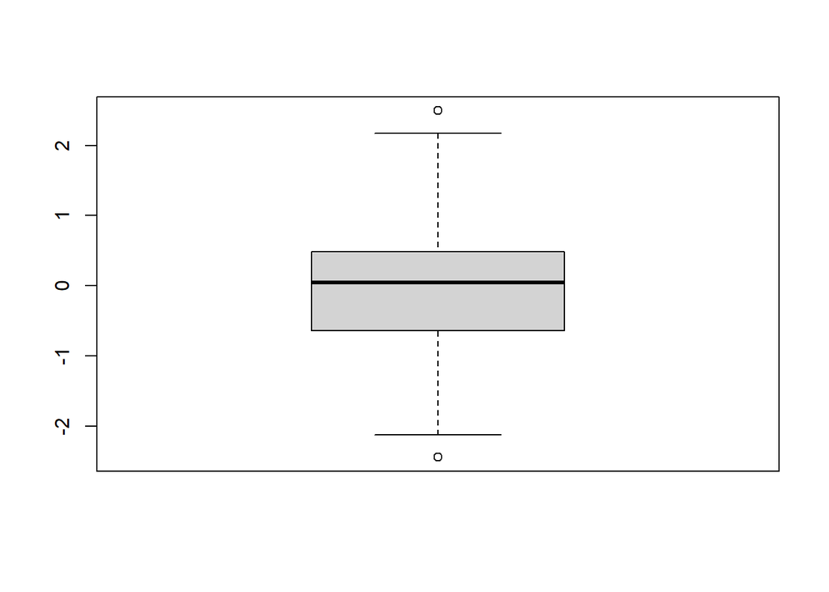

```r
boxplot(x.norm)
```

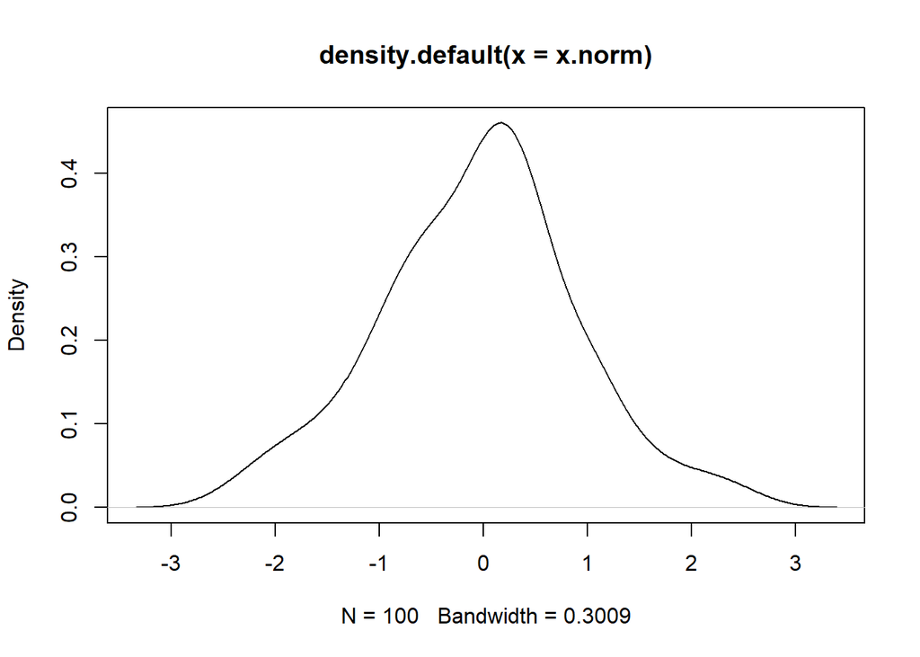

```r
plot(density(x.norm))
```

- Barchart: **barplot(x)**
- Piechart: **pie(x)**

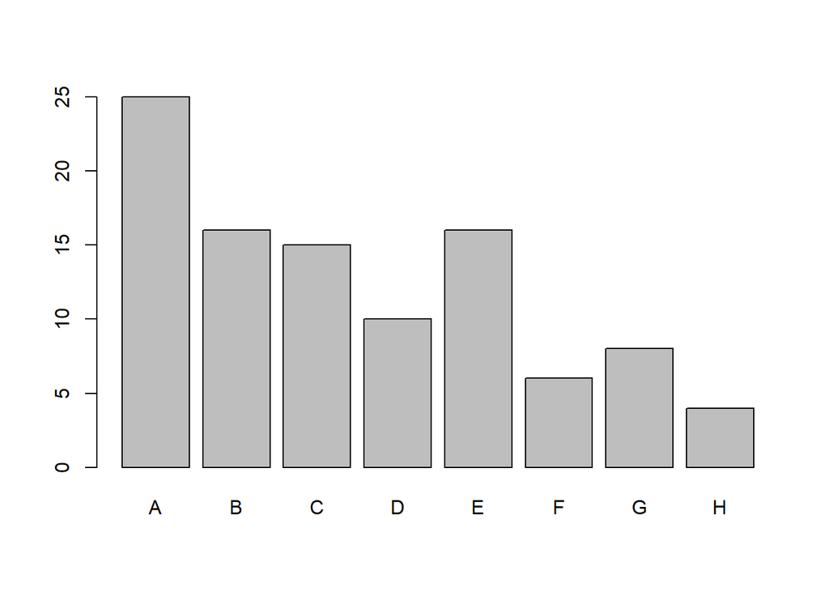

```r
x <- sample(c(1:8), 100, replace=TRUE, prob=c(8:1))
x <- table(x)
names(x) <- c("A", "B", "C", "D", "E", "F", "G", "H")
barplot(x)
```

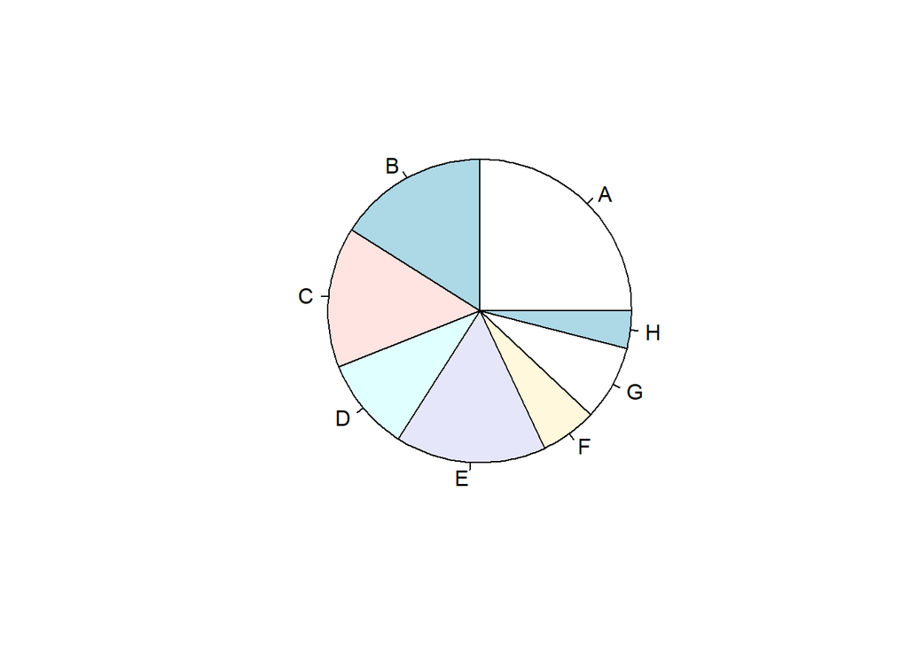

```r
pie(x)
```

## Scatter plots for two variables

Use **plot(x,y)**

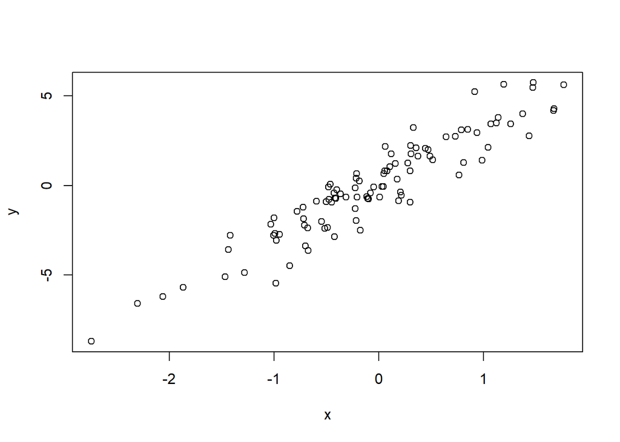

```r
x <- rnorm(100)
y <- 3*x + rnorm(100, 0, 1)
plot(x, y)
```

```r
cor(x,y)
```

```
## [1] 0.9372252
```

## Scatter plots for multiple variables

Use **pairs(. . . )**

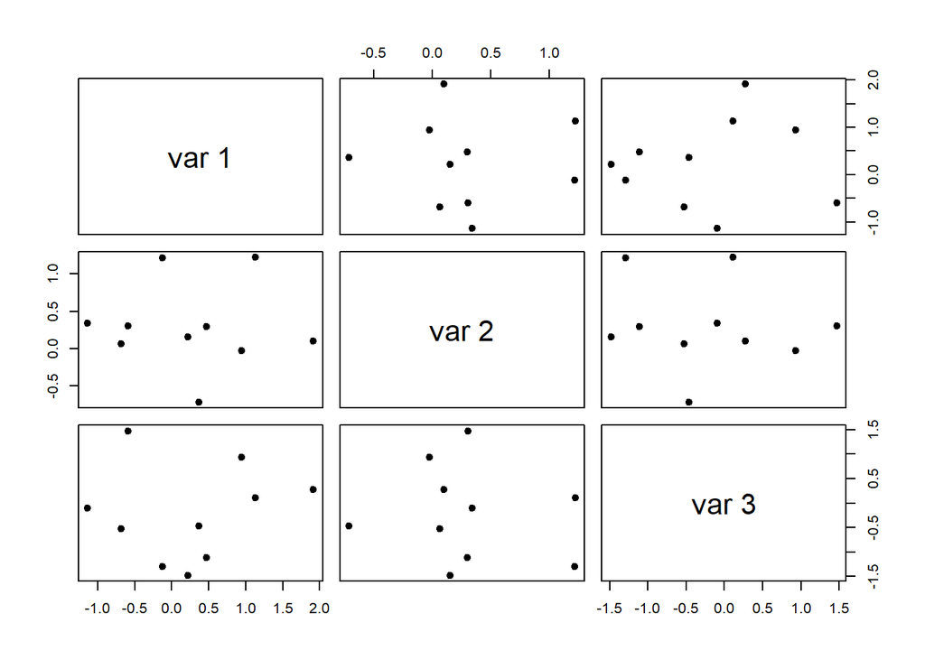

```r
X <- matrix(rnorm(30), 10, 3) ## use matrix
pairs(X, pch = 19)
```

## Boxplot for multiple categories

Use **boxplot(x)**

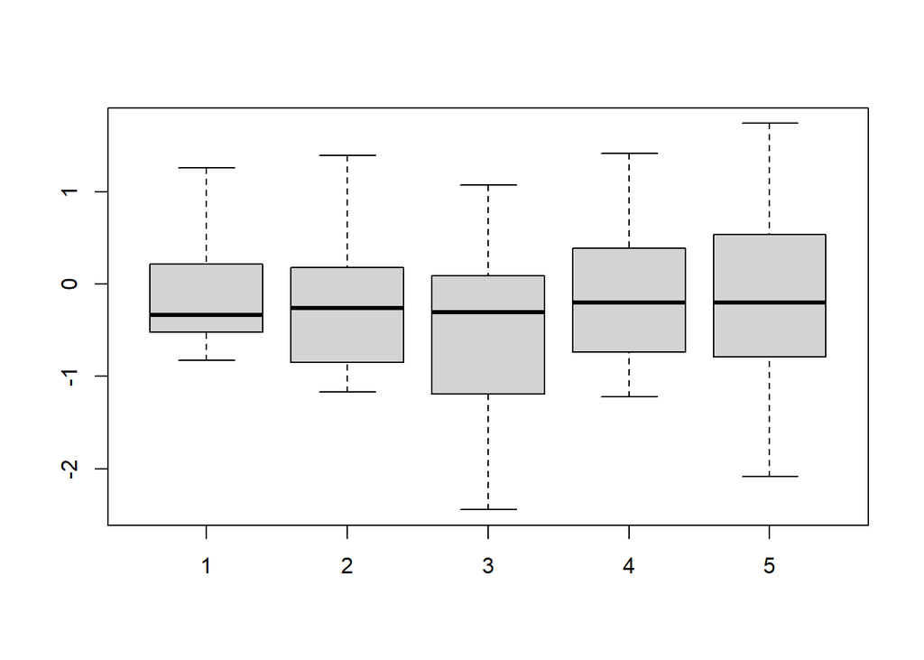

```r
## use matrix
X <- matrix(rnorm(50), 10, 5)
boxplot(X)
```

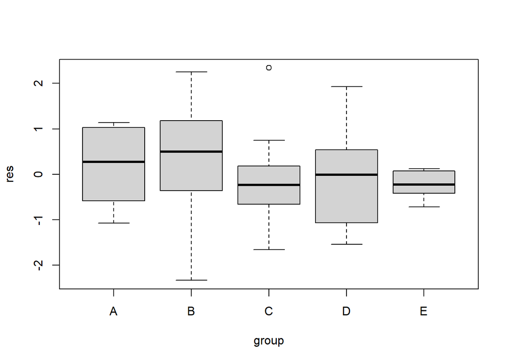

```r
## use data.frame
X <- data.frame(group = rep(c("A", "B", "C", "D", "E"), each = 10),
res = rnorm(50))
boxplot(res ~ group, data = X)
```

## **8-2 High-level plotting functions: Create a plot region with specifical items**

## General plot function: plot(. . . )

plot(x, y,

**type = “p”**, # types of the plot

**pch =** , # the symbol in the plot

**main = NULL**, # the title of the plot

**lty =** , # the style of a line

**lwd =** , # the width of a line

**cex =** , # the size of an text

**bty=“o”**, # the box around the plot

**col =** , # the color of an object

**xlim = NULL, ylim = NULL**, # the range of an axis

**sub = NULL**, # the sub-title of the plot

**xlab = NULL, ylab = NULL**, # the name of an axis

**cex.main =** # the size of the title

)

## plot(. . . , type = . . . )

“p”: points

“l”: lines

“b”: both points and lines

“o”: lines pass through points

“h”: the lines between points and x-axis

“n”: no content in the plot but plot region

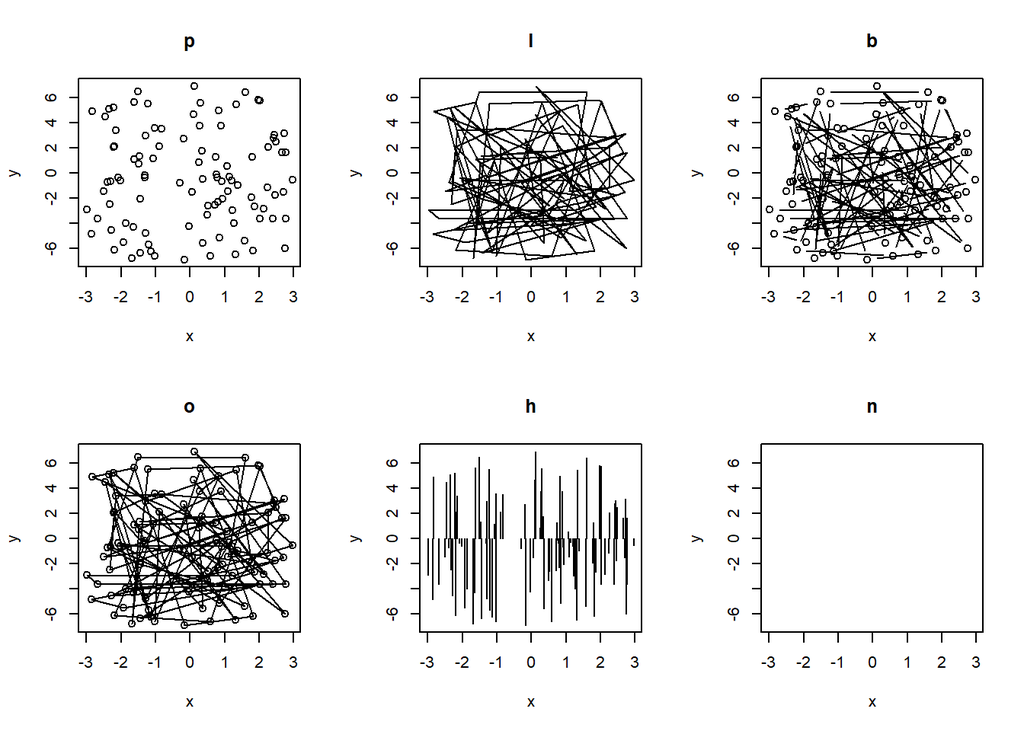

```r
x<-runif(100,-3,3)
y<-runif(100,-7,7)
par(mfrow = c(2,3)) # split plot ranges
plot(x, y, type = "p", main = "p")
plot(x, y, type = "l", main = "l")
plot(x, y, type = "b", main = "b")
plot(x, y, type = "o", main = "o")
plot(x, y, type = "h", main = "h")
plot(x, y, type = "n", main = "n")
```

## plot(. . . , pch = . . . )

pch = c(1, 2, …, 25, "*“,”.“,”o“,”O“,”0“,”+“,”-“,”|“,”%“,”#")

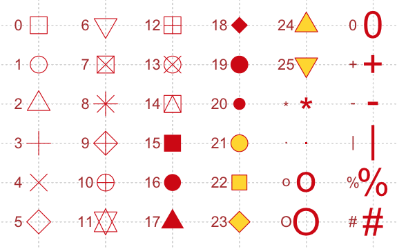

https://blog.gtwang.org/wp-content/uploads/2015/10/r-basic-plotting-tools-pch-1.png

## plot(. . . , cex = . . . )

Sizes in a plot: the number of times size of the default one

- Size of points: **cex = 1.5**
- Size of the title: **cex.main = 2**
- Size of the labels of ticks of an axis: **cex.axis = 2**
- Size of the labels of the name of an axis: **cex.lab = 2**

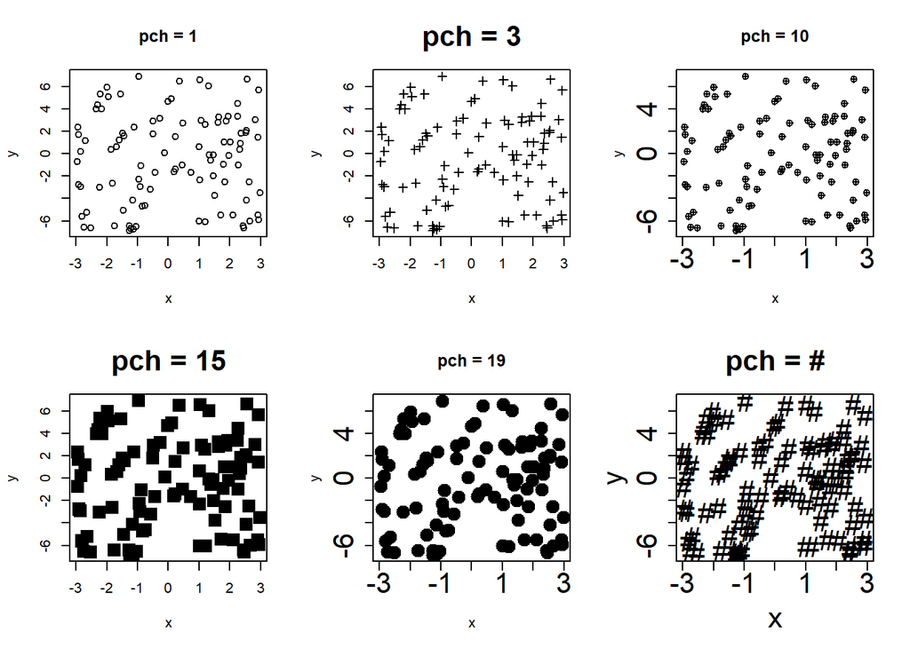

```r
x<-runif(100,-3,3)
y<-runif(100,-7,7)
par(mfrow = c(2,3)) # split plot ranges
plot(x, y, pch = 1, main = "pch = 1")
plot(x, y, pch = 3, main = "pch = 3", cex.main = 2)
plot(x, y, pch = 10, main = "pch = 10", cex.axis = 2)
plot(x, y, pch = 15, main = "pch = 15", cex = 2, cex.main = 2)
plot(x, y, pch = 19, main = "pch = 19", cex = 2, cex.axis = 2)
plot(x, y, pch = "#", main = "pch = #", cex = 2,
cex.axis = 2, cex.lab = 2, cex.main = 2)
```

## plot(. . . , type = “l”, lty =. . . , lwd = . . . )

Lines in the plot:

- The style of lines: **lty = 1, 2, . . . , 7**
- The width of lines: **lwd = 1, 1.25,. . .**

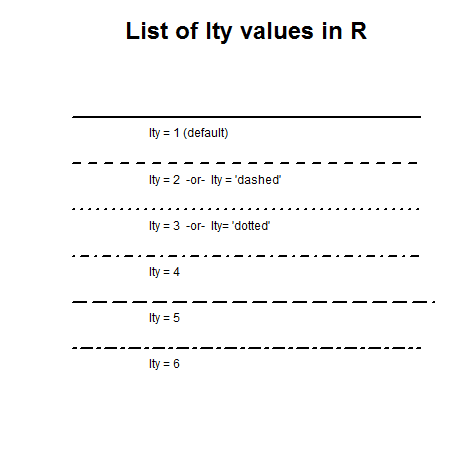

https://3.bp.blogspot.com/_GNAN4W4t4Lk/TKkEar3xD1I/AAAAAAAAAG8/DvGEJCpTCaM/s1600/lty.png

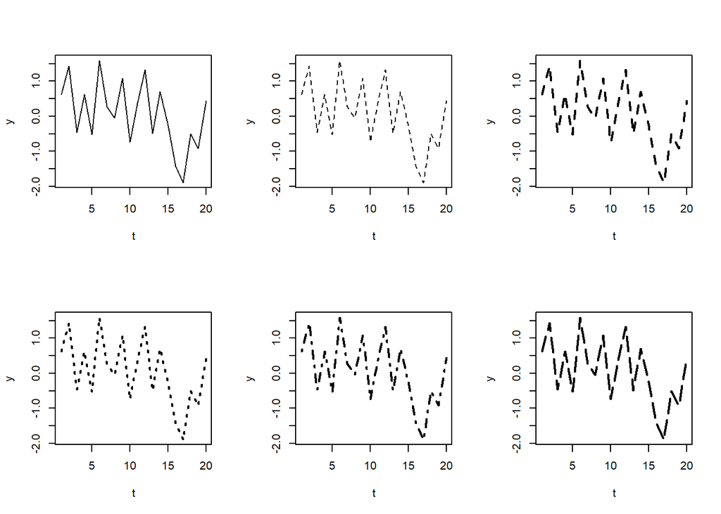

```r
t <- 1:20
y <- rnorm(20)
par(mfrow = c(2,3)) # split plot ranges
plot(t, y, type = "l")
plot(t, y, type = "l", lty = 2)
plot(t, y, type = "l", lty = 2, lwd = 2)
plot(t, y, type = "l", lty = 3, lwd = 2)
plot(t, y, type = "l", lty = 4, lwd = 2)
plot(t, y, type = "l", lty = 5, lwd = 2)
```

## plot(. . . , bty = . . . )

o: complete box (default parameter)

n: no box

7: top & right

L: bottom & left

C: top & left & bottom

U: left & bottom & right

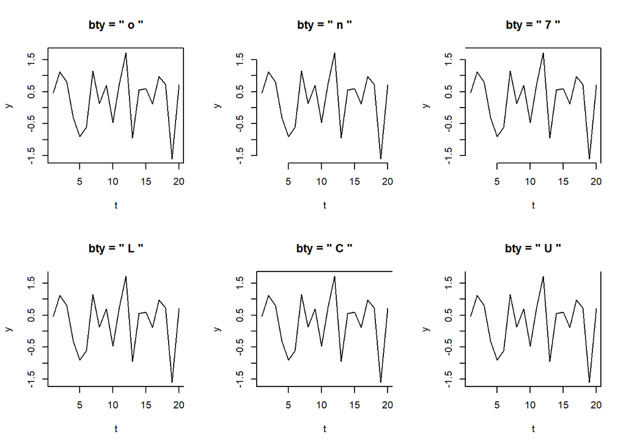

```r
t <- 1:20
y <- rnorm(20)
par(mfrow = c(2,3)) # split plot ranges
plot(t, y, type = "l", bty = "o", main = "bty = \" o \"")
plot(t, y, type = "l", bty = "n", main = "bty = \" n \"")
plot(t, y, type = "l", bty = "7", main = "bty = \" 7 \"")
plot(t, y, type = "l", bty = "L", main = "bty = \" L \"")
plot(t, y, type = "l", bty = "C", main = "bty = \" C \"")
plot(t, y, type = "l", bty = "U", main = "bty = \" U \"")
```

## plot(. . . , col = . . . )

Use **col** for colors.

- Use number: **col = c(1, 2, 3, 4, 5, 6, 7, 8)**
- Use name: **col = c(“red”, “green”, “blue”, “grey”)**
- Use hexadecimal code: **col = c(“#009999”, “#0000FF”, . . . )**
- More on colors: **help(palette)**

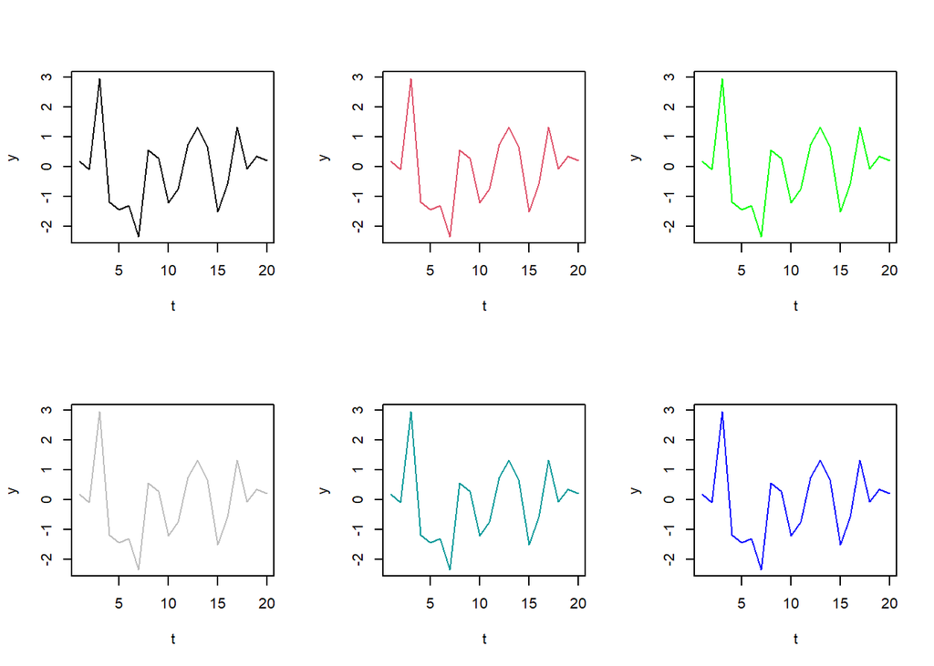

```r
t <- 1:20
y <- rnorm(20)
par(mfrow = c(2,3)) # split plot ranges
plot(t, y, type = "l", col = 1)
plot(t, y, type = "l", col = 2)
plot(t, y, type = "l", col = "green")
plot(t, y, type = "l", col = "grey")
plot(t, y, type = "l", col = "#009999")
plot(t, y, type = "l", col = "#0000FF")
```

## plot(. . . , main = . . . , sub = . . . , xlab = . . . , ylab = . . . )

Names of the plot:

**main**: main title (at the top)

**sub**: sub title (at the bottom)

**xlab**: name of x-axis

**ylab**: name of y-axis

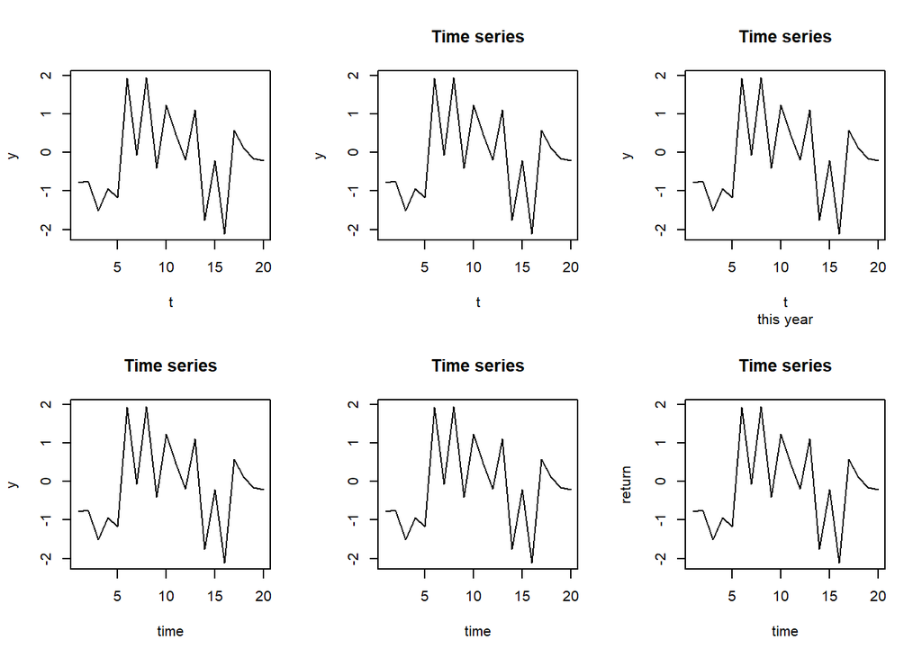

```r
t <- 1:20
y <- rnorm(20)
par(mfrow = c(2,3)) # split plot ranges
plot(t, y, type = "l")
plot(t, y, type = "l", main = "Time series")
plot(t, y, type = "l", main = "Time series", sub = "this year")
plot(t, y, type = "l", main = "Time series", xlab = "time")
plot(t, y, type = "l", main = "Time series", xlab = "time",
ylab = "")
plot(t, y, type = "l", main = "Time series", xlab = "time",
ylab = "return")
```

## plot(. . . , xlim = . . . , ylim = . . . )

Ranges of variables **xlim** = c(a, b): a ≤ x ≤ b **ylim** = c(a, b): a ≤ y ≤ b

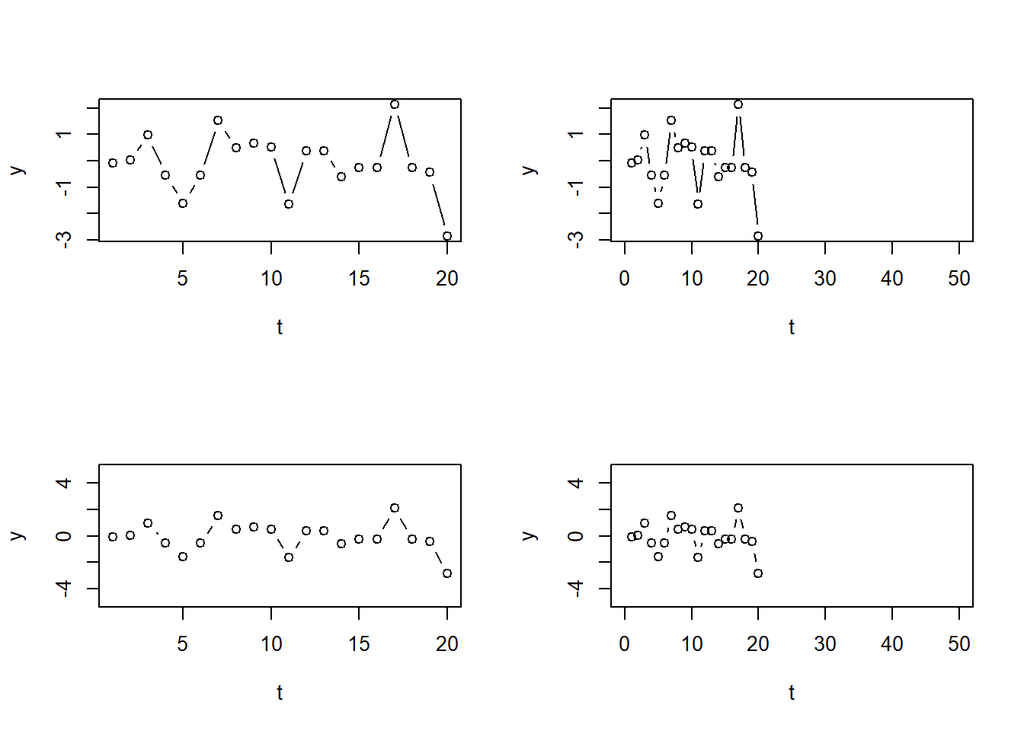

```r
t <- 1:20
y <- rnorm(20)
par(mfrow = c(2,2)) # split plot ranges
plot(t, y, type = "b")
plot(t, y, type = "b", xlim = c(0, 50))
plot(t, y, type = "b", ylim = c(-5, 5))
plot(t, y, type = "b", xlim = c(0, 50), ylim = c(-5, 5))
```

## curve(. . . )

Instead of using plot(x, y, type = “l”), use **curve(expression, from = …, to = …)** to draw a function of a variable.

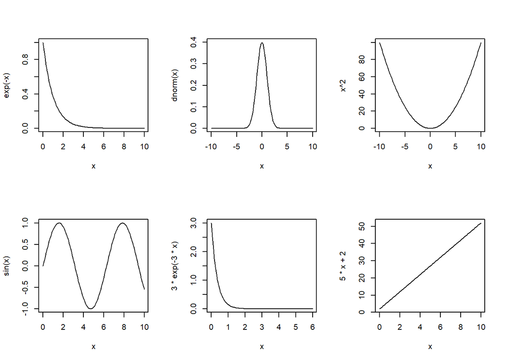

```r
par(mfrow = c(2, 3))
curve(exp(-x), 0, 10)
curve(dnorm(x), -10, 10)
curve(x^2, -10, 10)
curve(sin, 0, 10)
curve(3*exp(-3*x), 0, 6)
curve(5*x+2, 0, 10)
```

## **8-3 Low-level plotting functions: Add some objects to the existing plot**

Add points or lines to an existing plot

**points(. . . )**: add points

**lines(. . . )**: add lines

**abline(. . . )**: add straight lines

*abline(a = …, b = …, h = …, v = …, reg = …, coef = …)*

### Example1

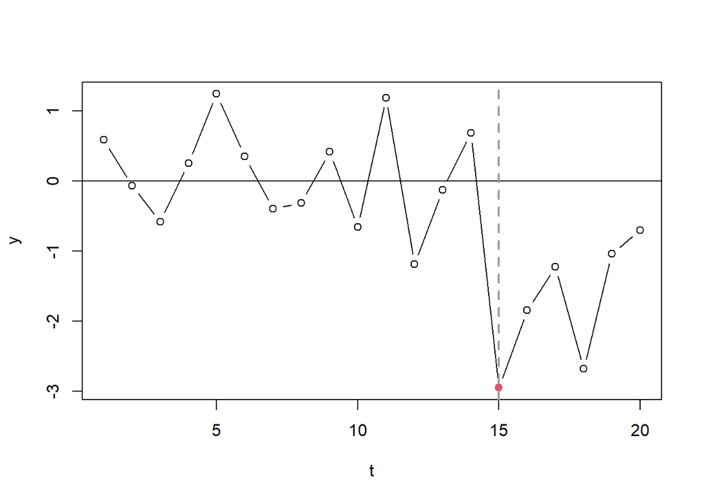

```r
t <- 1:20
y <- rnorm(20)
plot(t, y, type = "b")
abline(h = 0)
abline(v = 15, lty = 2, col = 8, lwd = 2)
points(t[15], y[15], pch = 19, col = 2)
```

### Example2

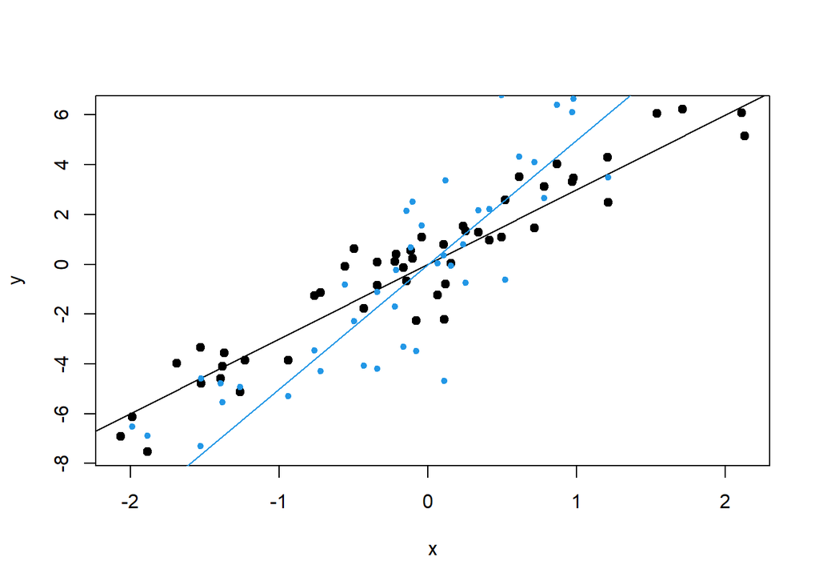

```r
x <- rnorm(50)
y <- 3*x + rnorm(50, 0, 1)
y1 <- 5*x + rnorm(50, 0, 2)
plot(x, y, type = "p", pch = 19)
abline(a = 0, b = 3)
points(x, y1, col = 4, pch = 20)
abline(a = 0, b = 5, col = 4)
```

## Add text to an existing plot

Arbitrary locations: **text(x, y, labels = . . . )**

Notations of objects in the plot: **legend(x, y, legend, . . . )**

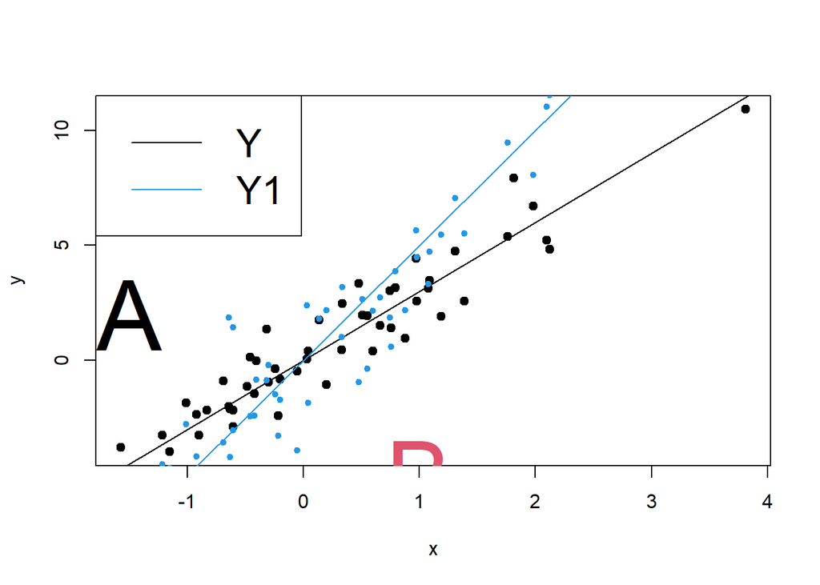

```r
x <- rnorm(50)
y <- 3*x + rnorm(50, 0, 1)
y1 <- 5*x + rnorm(50, 0, 2)
plot(x, y, type = "p", pch = 19)
abline(a = 0, b = 3)
points(x, y1, col = 4, pch = 20)
abline(a = 0, b = 5, col = 4)
text(-1.5, 2, "A", cex = 5)
text(1, -5, "B", cex = 5, col = 2)
legend("topleft", c("Y", "Y1"), col = c(1,4), lty = c(1, 1),
cex = 2)
```

## Re-arrange the region of a figure

Use **par(. . . )** to creat an arbitrary region

**mfrow = c(2, 2)**: Define a multi-figure display by row

**mfcol = c(2, 2)**: Define a multi-figure display by column

**mai, mar = c(3, 3, 1, 1)**: The four margin sizes, in inches (mai), or in text line units (mar).

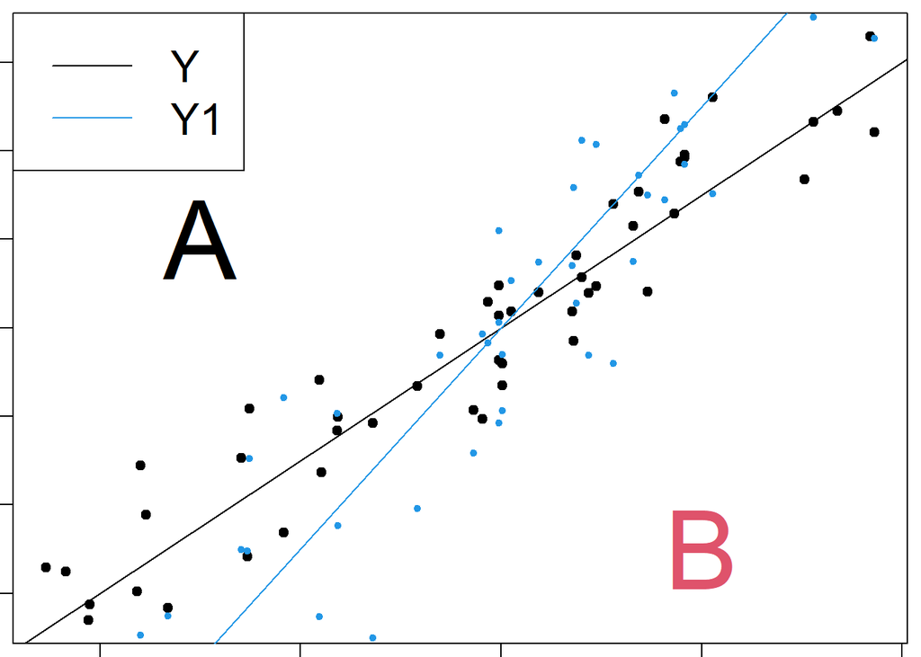

```r
x <- rnorm(50)
y <- 3*x + rnorm(50, 0, 1)
y1 <- 5*x + rnorm(50, 0, 2)
par(mfrow = c(1, 1), mar = c(0.5, 0.5, 0.5, 0.5))
plot(x, y, type = "p", pch = 19)
abline(a = 0, b = 3)
points(x, y1, col = 4, pch = 20)
abline(a = 0, b = 5, col = 4)
text(-1.5, 2, "A", cex = 5)
text(1, -5, "B", cex = 5, col = 2)
legend("topleft", c("Y", "Y1"), col = c(1,4), lty = c(1, 1),
cex = 2)
```

## Split the whole plot by some locations of plot

Use **layout(. . . )**

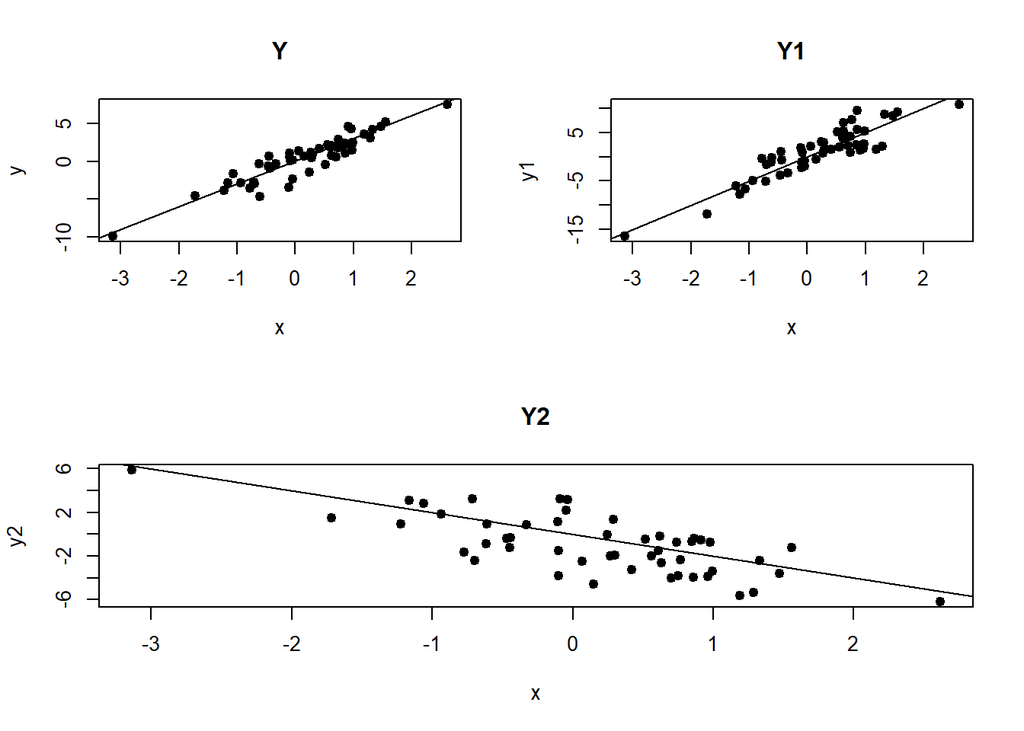

```r
x <- rnorm(50)
y <- 3*x + rnorm(50, 0, 1)
y1 <- 5*x + rnorm(50, 0, 2)
y2 <- -2*x + rnorm(50, 0, 2)
layout(matrix(c(1,2,3,3), 2, 2, byrow=TRUE))
plot(x, y, type = "p", pch = 19, main = "Y")
abline(a = 0, b = 3)
plot(x, y1, type = "p", pch = 19, main = "Y1")
abline(a = 0, b = 5)
plot(x, y2, type = "p", pch = 19, main = "Y2")
abline(a = 0, b = -2)
```